# salaries slides

## Do men earn more than women?

```python
dataset = pd.read_csv("fr-2017-pssd-compendium-20180320-utf8.csv")
dataset.head(5)
```

|  | Secteur | Nom de famille | Prénom | Traitement versé | Avantages imposables | Employeur | Poste | Année civile |
| --- | --- | --- | --- | --- | --- | --- | --- | --- |
| 0 | Autres employeurs du secteur public | Coleridge | Peter | $250,000.00 | $25,749.50 | Big Brothers Big Sisters of Canada | National President and Chief Executive Officer | 2017 |
| 1 | Autres employeurs du secteur public | Chater | W. Matthew | $100,877.00 | $2,778.27 | Big Brothers Big Sisters of Canada | National Vice-President, Service and Organizat... | 2017 |
| 2 | Autres employeurs du secteur public | Mcintyre | Mary Ellen | $113,847.58 | $19,015.00 | Centre For Spanish Speaking Peoples | Legal Director | 2017 |
| 3 | Autres employeurs du secteur public | Marlin | Susan | $248,068.75 | $258.48 | Clinical Trials Ontario | President and Chief Executive Officer | 2017 |
| 4 | Autres employeurs du secteur public | Frampton | Peter | $165,033.85 | $10,788.30 | Learning Enrichment Foundation | Executive Director | 2017 |

How many people do we have? About 130 thousands.

```python
dataset.shape
```

```
(131741, 8)
```

It looks good but the file contains numbers as "$113,847.58". It is not recognized by Python as a number. So we need to remove the '$' and the ',' before we can parse it as a number. So we call the "replace" function.

```python
dataset["salaire"]=dataset['Traitement versé'].replace( '[\$,]','', regex=True ).astype(float) + dataset['Avantages imposables'].replace( '[\$,]','', regex=True ).astype(float)
pd.options.display.float_format = '${:,.2f}'.format
```

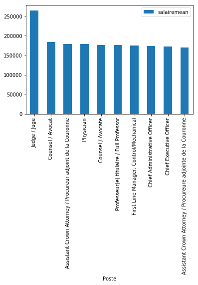

```python
salaireparposte=dataset.groupby("Poste").agg({'salaire':[np.size,np.mean]}).reset_index()
salaireparposte=salaireparposte[salaireparposte[("salaire","size")]>200].sort_values(("salaire","mean"),ascending=False)
salaireparposte.columns = [col[0]+col[1] for col in salaireparposte.columns]

salaireparposte[["Poste","salairemean"]].set_index('Poste').head(10).plot.bar()
```

```python
dataset.head(5)
```

|  | Secteur | Nom de famille | Prénom | Traitement versé | Avantages imposables | Employeur | Poste | Année civile | salaire |
| --- | --- | --- | --- | --- | --- | --- | --- | --- | --- |
| 0 | Autres employeurs du secteur public | Coleridge | Peter | $250,000.00 | $25,749.50 | Big Brothers Big Sisters of Canada | National President and Chief Executive Officer | 2017 | $275,749.50 |
| 1 | Autres employeurs du secteur public | Chater | W. Matthew | $100,877.00 | $2,778.27 | Big Brothers Big Sisters of Canada | National Vice-President, Service and Organizat... | 2017 | $103,655.27 |
| 2 | Autres employeurs du secteur public | Mcintyre | Mary Ellen | $113,847.58 | $19,015.00 | Centre For Spanish Speaking Peoples | Legal Director | 2017 | $132,862.58 |
| 3 | Autres employeurs du secteur public | Marlin | Susan | $248,068.75 | $258.48 | Clinical Trials Ontario | President and Chief Executive Officer | 2017 | $248,327.23 |
| 4 | Autres employeurs du secteur public | Frampton | Peter | $165,033.85 | $10,788.30 | Learning Enrichment Foundation | Executive Director | 2017 | $175,822.15 |

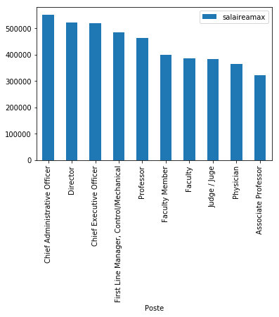

```python
salaireparposte=dataset.groupby("Poste").agg({'salaire':[np.size,np.max]}).reset_index()
salaireparposte=salaireparposte[salaireparposte[("salaire","size")]>200].sort_values(("salaire","amax"),ascending=False)
salaireparposte.columns = [col[0]+col[1] for col in salaireparposte.columns]

salaireparposte[["Poste","salaireamax"]].set_index('Poste').head(10).plot.bar()
```

```python
profsalaire = dataset[dataset['Poste'].str.contains("Prof") & ~(dataset['Poste'].str.contains("Dean"))]
profsalaire.sort_values("salaire",ascending=False)[["Nom de famille","Employeur","salaire"]].head(100)
```

|  | Nom de famille | Employeur | salaire |
| --- | --- | --- | --- |
| 126061 | Ganjavi | Laurentian University of Sudbury | $686,965.86 |
| 129478 | Hull | University of Toronto | $465,324.29 |
| 122755 | Yusuf | Mcmaster University | $462,846.17 |
| 128612 | Christoffersen | University of Toronto | $457,575.56 |
| 130294 | Mitchell | University of Toronto | $451,223.87 |
| 131556 | Whyte | University of Toronto | $449,973.45 |
| 131210 | Strange | University of Toronto | $442,910.28 |
| 128033 | Aivazian | University of Toronto | $441,261.26 |
| 130167 | Mccurdy | University of Toronto | $436,216.96 |
| 128022 | Agrawal | University of Toronto | $428,082.50 |
| 131125 | Soman | University of Toronto | $424,189.00 |
| 130566 | Pauly | University of Toronto | $420,790.32 |
| 128207 | Baum | University of Toronto | $419,325.79 |
| 129319 | Han | University of Toronto | $414,077.12 |
| 122398 | Panju | Mcmaster University | $413,113.36 |
| 129384 | Hejazi | University of Toronto | $408,842.06 |
| 130946 | Schneider | University of Toronto | $405,333.81 |
| 129056 | Florida | University of Toronto | $405,251.64 |
| 131115 | Soberman | University of Toronto | $403,905.40 |
| 130912 | Sargent | University of Toronto | $398,555.70 |
| 130838 | Rotenberg | University of Toronto | $397,091.80 |
| 129209 | Goldreich | University of Toronto | $396,211.12 |
| 121811 | Crowther | Mcmaster University | $395,275.80 |
| 130281 | Misak | University of Toronto | $392,167.74 |
| 131056 | Silverman | University of Toronto | $389,464.62 |
| 113669 | Woolf | Queen's University | $386,629.92 |
| 113936 | Levin | Queen's University | $384,121.88 |
| 128908 | Dyck | University of Toronto | $384,073.10 |
| 129129 | Gans | University of Toronto | $384,064.68 |
| 130414 | Naylor | University of Toronto | $381,503.40 |
| ... | ... | ... | ... |
| 51052 | Alexopoulou | Hamilton Health Sciences | $336,130.62 |
| 120573 | Foerster | University of Western Ontario | $335,005.50 |
| 122390 | Orovan | Mcmaster University | $334,696.70 |
| 129942 | Li | University of Toronto | $332,684.88 |
| 129566 | John | University of Toronto | $332,475.30 |
| 128666 | Collingridge | University of Toronto | $331,715.52 |
| 120271 | Bansal | University of Western Ontario | $331,338.76 |
| 113769 | Anger | Queen's University | $330,174.28 |
| 130328 | Moorthy | University of Toronto | $329,902.14 |
| 121784 | Collins | Mcmaster University | $329,506.26 |
| 131071 | Simutin | University of Toronto | $329,392.79 |
| 128343 | Bova | University of Toronto | $328,917.44 |
| 124575 | Madhok | York University | $328,501.08 |
| 122442 | Price | Mcmaster University | $327,852.73 |
| 128332 | Booth | University of Toronto | $327,368.44 |
| 120294 | Beamish | University of Western Ontario | $326,990.74 |
| 130406 | Najm | University of Toronto | $325,777.62 |
| 131348 | Tombak | University of Toronto | $325,155.89 |
| 130784 | Ripstein | University of Toronto | $325,116.12 |
| 124511 | Levesque | York University | $323,129.04 |
| 121273 | Sapp | University of Western Ontario | $322,940.92 |
| 121845 | Denburg | Mcmaster University | $322,786.03 |
| 129227 | Gotlieb | University of Toronto | $322,649.48 |
| 120811 | Kim | University of Western Ontario | $321,444.96 |
| 130772 | Richardson | University of Toronto | $321,395.34 |
| 120370 | Busaba | University of Western Ontario | $320,882.58 |
| 129493 | Hyatt | University of Toronto | $320,876.09 |
| 131170 | Stein | University of Toronto | $320,327.48 |
| 127366 | Elayan | Brock University | $319,818.78 |
| 130787 | Roach | University of Toronto | $319,360.28 |

100 rows × 3 columns

Ok. So we have the dataset, but there is no gender identification. Thankfully, there are available statistical models that allow us to categorize first names.

```python
genderstat =  pd.read_csv("us-likelihood-of-gender-by-name-in-2014.csv")
genderstat[["sex","name"]].head()
```

|  | sex | name |
| --- | --- | --- |
| 0 | F | Elaine |
| 1 | F | Cathy |
| 2 | F | Heidi |
| 3 | F | Vicki |
| 4 | F | Melinda |

But first, let us check that things work as they should:

```python
from unidecode import unidecode
def gender_first_name(name):
    try:
      return genderstat[genderstat['name'].map(lambda x : unidecode(x))==unidecode(name)][["sex"]].values[0][0]
    except:
      return "UNKNOWN"
for n in ["Nathalie", "Julie", "Pierre", "Yves", "Daniel", "Lohan"]:
    print(n, gender_first_name(n))
```

```
Nathalie F
Julie F
Pierre M
Yves M
Daniel M
Lohan UNKNOWN
```

Ok. So now we have two tables. What are we going to do to put the data back together? One solution is to use a "join".

We have a 'name' column in one dataset, and now we will create another name column on the other data set, after making sure to trim out accents so that "Éric" becomes "Eric".

```python
from unidecode import unidecode
dataset['name'] = dataset['Prénom'].apply(lambda n : unidecode(n) )
dataset[['name','Prénom']].head(10)
```

|  | name | Prénom |
| --- | --- | --- |
| 0 | Peter | Peter |
| 1 | W. Matthew | W. Matthew |
| 2 | Mary Ellen | Mary Ellen |
| 3 | Susan | Susan |
| 4 | Peter | Peter |
| 5 | Therese | Therese |
| 6 | Daniel | Daniel |
| 7 | Deborah | Deborah |
| 8 | Shirley | Shirley |
| 9 | Sue | Sue |

```python
datasetwithgender=pd.merge(dataset,genderstat,on="name")
```

```python
datasetwithgender.groupby("sex").size()
```

```
sex
F    43315
M    58417
dtype: int64
```

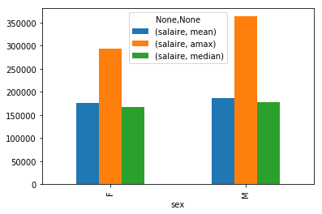

```python
datasetwithgender[datasetwithgender["Poste"]=="Physician"].groupby(["sex"]).agg({'salaire':[np.mean,np.max,np.median]}).plot.bar()
```

```python
datasetwithgender.groupby("sex").agg({'salaire':np.mean})
```

| sex | salaire |
| --- | --- |
| F | $123,879.68 |
| M | $130,332.61 |

```python
datasetwithgender.groupby("sex").agg({'salaire':np.max})
```

| sex | salaire |
| --- | --- |
| F | $745,268.93 |
| M | $1,561,320.95 |

```python
waterlooprofessor = datasetwithgender[(datasetwithgender["Employeur"]=="University of Waterloo")
                                      &(datasetwithgender["Poste"].str.contains("Professor"))]
```

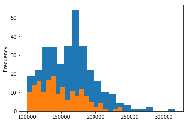

```python
waterlooprofessor[waterlooprofessor["sex"]=="M"]["salaire"].plot.hist( bins=20)
waterlooprofessor[waterlooprofessor["sex"]=="F"]["salaire"].plot.hist( bins=20)
```

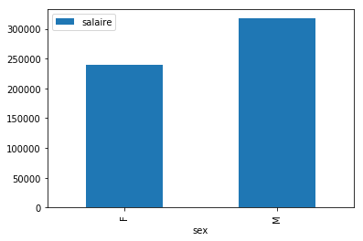

```python
waterlooprofessor.groupby("sex").agg({'salaire':np.max}).plot.bar()
```

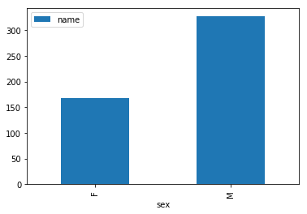

```python
waterlooprofessor.groupby("sex").agg({'name':np.size}).plot.bar()
```

```python
ottawaprofessor = datasetwithgender[(datasetwithgender["Employeur"]=="University of Ottawa")
                                      &(datasetwithgender["Poste"].str.contains("Professeur"))]
ottawaprofessor[['name','sex',"salaire"]].head(5)
```

|  | name | sex | salaire |
| --- | --- | --- | --- |
| 796 | Peter | M | $185,750.40 |
| 797 | Peter | M | $153,990.13 |
| 798 | Peter | M | $153,903.36 |
| 800 | Peter | M | $179,153.60 |
| 801 | Peter | M | $185,766.00 |

```python
ottawaprofessor.groupby("sex").agg({'salaire':np.mean})
```

| sex | salaire |
| --- | --- |
| F | $147,084.86 |
| M | $156,445.92 |

```python
ottawaprofessor.groupby("sex").agg({'salaire':np.max})
```

| sex | salaire |
| --- | --- |
| F | $237,641.00 |
| M | $260,765.92 |

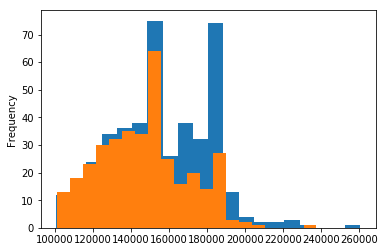

```python
ottawaprofessor[ottawaprofessor["sex"]=="M"]["salaire"].plot.hist( bins=20)
ottawaprofessor[ottawaprofessor["sex"]=="F"]["salaire"].plot.hist( bins=20)
```